# 산업공학특론I_중간고사

강상빈 (2024197748)

4/10/2024

### [중간고사 개요]

#### 1. 중간고사 답안 작성 및 제출 요령

- 모든 답안 도출 과정은 R 코드로 작성되어야 하며, 코드에는 분석 과정을 식별할 수 있도록 주석(#)으로 설명이 작성되어야 한다. (R 코드 없이 답만 적는 경우 오답 처리)
- 수강생 간 코드를 공유하거나 동일하게 작성하는 행위를 금지한다. (적발 시 진실의 방 소환 및 모두 0점으로 성적 반영)
- 특정한 문제에 대한 답안은 해당 문항에 대한 코드에 작성되어야 한다. (1번 문항에 대한 답을 2번 문항에 적는 경우 오답 처리)
- 답안은 Rmd 확장자로 보고서 제작이 가능하도록 제출하는 것을 원칙으로 하나, Markdown 실행이 어려운 경우 R 스크립트로 작성하되 채점이 가능하도록 문항 별로 스크립트를 작성하여야 한다.
- 중간고사 답안은 4월 10일 23시 59분까지 온라인 강의실 내 과제 및 평가 - 중간고사 탭에 제출하여야 하며, 4월 11일 자정 이후에는 제출이 불가하다. (이후 다른 경로를 통하여 제출 시 총점의 50%로 성적 반영)

#### 2. 데이터 설명

어느 의류 생산 공정에서는 재봉 (sewing), 마감 (finishing)으로 부서를 구성하여 공정을 운영하고 있으며, 공정의 생산성을 개선하기 위해 일별 공정 작업 관련 데이터를 수집하여 생산성에 영향을 미치는 요인을 분석하고자 한다. 데이터 분석에 활용하는 변수의 정보는 다음과 같다.

- date: 집계 날짜
- quarter: 한 달을 나눈 분기 (주)
- department: 부서
- day: 요일
- team: 부서별 투입 인원 수
- targeted_productivity: 당초에 목표한 생산성 점수
- over_time: 초과근무 (분)
- incentive: 성과급
- actual_productivity: 실제 생산성 점수

상기에 기술된 작성요령과 데이터를 기반으로 주어진 문제에 대한 분석 과정과 그에 따른 답안을 기술하시오.

### [중간고사 문항]

#### 1. 주어진 데이터에서 데이터 탐색 (EDA) 및 전처리를 수행하고, 결과를 시각화하시오. (10점)

- 활용하지 않는 변수 (date, smv, wip, idle_time, idle_men, no_of_style_change, no_of_workers)는 삭제할 것
- 시각화 시 범주형 변수는 막대그래프로, 연속형 변수는 히스토그램으로 표현할 것

```r
#데이터 불러온 후 전처리
dat <- read.csv('산업공학특론I_중간고사 데이터.csv')
ls(dat)
```

```
##  [1] "actual_productivity"   "date"                  "day"
##  [4] "department"            "idle_men"              "idle_time"
##  [7] "incentive"             "no_of_style_change"    "no_of_workers"
## [10] "over_time"             "quarter"               "smv"
## [13] "targeted_productivity" "team"                  "wip"
```

```r
# 삭제할 변수 선택
dat_rm <- c("date", "smv", "wip", "idle_time", "idle_men", "no_of_style_change", "no_of_workers")

# 선택한 변수 삭제
dat <- dat[, !(names(dat) %in% dat_rm)]
head(dat)
```

```
##    quarter department      day team targeted_productivity over_time incentive
## 1 Quarter1     sweing Thursday    8                  0.80      7080        98
## 2 Quarter1 finishing  Thursday    1                  0.75       960         0
## 3 Quarter1     sweing Thursday   11                  0.80      3660        50
## 4 Quarter1     sweing Thursday   12                  0.80      3660        50
## 5 Quarter1     sweing Thursday    6                  0.80      1920        50
## 6 Quarter1     sweing Thursday    7                  0.80      6720        38
##   actual_productivity
## 1           0.9407254
## 2           0.8865000
## 3           0.8005705
## 4           0.8005705
## 5           0.8003819
## 6           0.8001250
```

```r
# 문자형 변수들을 범주형으로 변경
dat$quarter <- as.factor(dat$quarter)
dat$day <- as.factor(dat$day)

# 시각화 과정에서 department변수의 finishing값이 공백으로 인해 2가지로 나뉘는 것을 확인하여 공백을 제거하여 하나로 통합
# 그 후 문자형 데이터를 범주형으로 변환
dat$department <- trimws(dat$department)
dat$department <- as.factor(dat$department)

summary(dat)
```

```
##      quarter        department         day           team
##  Quarter1:360   finishing:506   Monday   :199   Min.   : 1.000
##  Quarter2:335   sweing   :691   Saturday :187   1st Qu.: 3.000
##  Quarter3:210                   Sunday   :203   Median : 6.000
##  Quarter4:248                   Thursday :199   Mean   : 6.427
##  Quarter5: 44                   Tuesday  :201   3rd Qu.: 9.000
##                                 Wednesday:208   Max.   :12.000
##  targeted_productivity   over_time       incentive       actual_productivity
##  Min.   :0.0700        Min.   :    0   Min.   :   0.00   Min.   :0.2337
##  1st Qu.:0.7000        1st Qu.: 1440   1st Qu.:   0.00   1st Qu.:0.6503
##  Median :0.7500        Median : 3960   Median :   0.00   Median :0.7733
##  Mean   :0.7296        Mean   : 4567   Mean   :  38.21   Mean   :0.7351
##  3rd Qu.:0.8000        3rd Qu.: 6960   3rd Qu.:  50.00   3rd Qu.:0.8503
##  Max.   :0.8000        Max.   :25920   Max.   :3600.00   Max.   :1.1204
```

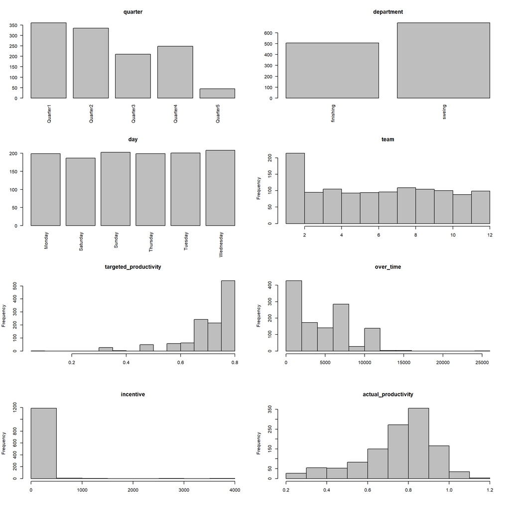

```r
# 데이터 탐색을 위한 시각화 수행
# 이 때, 범주형은 막대그래프, 연속형은 히스토그램으로 분포 시각화하도록 함수 작성
visualize <- function(x,main){
  if (is.factor(x)){ barplot(table(x), col='grey', main=main, las=2)
  } else { hist(x, col='grey', main=main, xlab='') }
}

  # 4행 2열 배치로 시각화 진행
par(mfrow=c(4,2))
for (i in 1:ncol(dat)){ visualize(x=dat[,i], main=colnames(dat)[i]) }
```

#### 2. 실제 생산성 점수 (actual_productivity)가 어떠한 분포를 따르는지 규명하기 위하여 여러 분포에 대한 MLE를 추정 및 비교하고, 최적 분포를 도출하시오. (15점)

- 여러 분포 (최소 2개 이상)에 대하여 MLE를 통하여 모수를 추정할 것
- 분포별 추정 결과 비교 시 적합도 평가 지표를 활용할 것
- 추정 결과에 따른 최적 분포를 도출하고, 그 근거를 제시할 것

```r
# 확률분포 관련 라이브러리 로드
library(fitdistrplus)
# MLE을 추정을 위한 데이터 추출
dat_actprod <- dat$actual_productivity

fit <- function(x){

  # 후보 확률분포 정의 # 지수분포, 감마분포, 정규분포
  fitlist <- c('exp','gamma','norm')

    # 추정 파라미터와 로그우도값을 추정한 결과를 정리할 틀 생성
    result <- matrix(nrow=3, ncol=length(fitlist))
    colnames(result) <- fitlist #exp, gamma, norm
    row.names(result) <- c('par1','par2','loglike')

    # 지정한 후보 확률분포를 각각 추정하여 결과를 틀에 입력
    for (j in 1:length(fitlist)){
      fit_temp <- fitdist(x, fitlist[j])

      est <- fit_temp$estimate #모수추정시에 모수갯수 차이로 발생하는 오류를 방지
      if (length(est)==1){ est <- c(est,NA)}

      ll <- fit_temp$loglik
      result[,j] <- c(est, ll)
    }
    print(result) # 결과 출력

# 로그우도값이 가장 큰 확률분포를 적합 분포로 선정하여 출력
# 최대우도추정법을 기반으로 모수를 추정하는 관계로, 로그우도값이 큰 값이 나오는 분포가 데이터를 잘 설명한다고 판단
    best <- colnames(result)[which.max(result[3,])]
    print(paste('그룹의 최적 분포는',best,'입니다.'))
}

fit(dat_actprod)
```

```
##                 exp     gamma        norm
## par1       1.360376  13.98194   0.7350911
## par2             NA  19.02084   0.1744150
## loglike -828.610267 277.69735 391.8729179
## [1] "그룹의 최적 분포는 norm 입니다."
```

#### 3. 2. 에서 도출된 최적 분포를 기준으로 MLE 추정 결과를 시각화하고 이를 해석하시오. (10점)

- 시각화의 경우 실제 데이터의 분포와 MLE를 모수로 가지는 분포의 비교가 가능하도록 도시할 것
- 단순 도시가 아닌 도시 결과에 대한 해석 결과를 설명하고, 결론을 도출할 것

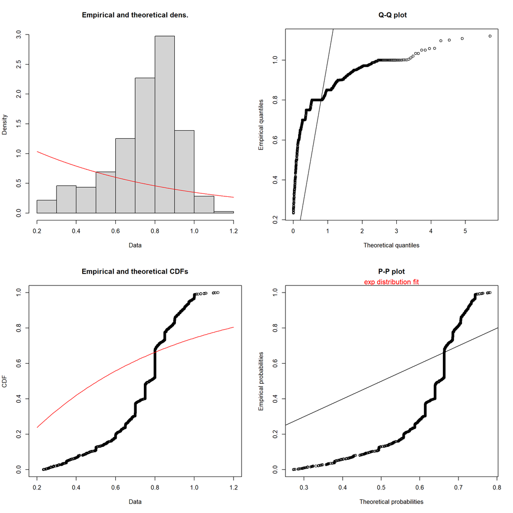

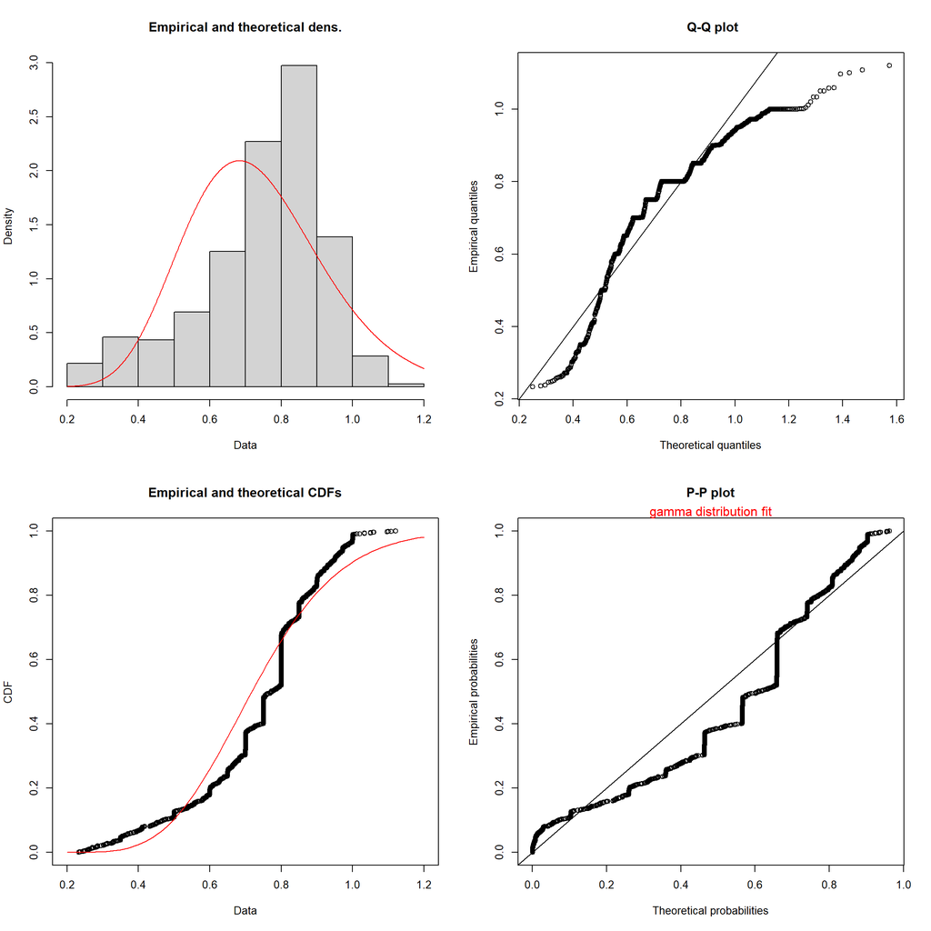

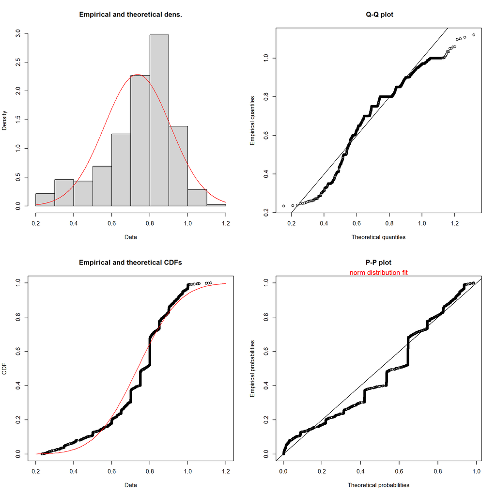

```r
fit_visualize <- function(x){

  # 후보 확률분포 정의
  fitlist <- c('exp', 'gamma', 'norm')
  fit_objects <- list()

  # 추정 파라미터와 로그우도값을 추정한 결과를 정리할 틀 생성
  result <- matrix(nrow=3, ncol=length(fitlist))
  colnames(result) <- fitlist #exp, gamma, norm
  row.names(result) <- c('par1','par2','loglike')

  # 지정한 후보 확률분포를 각각 추정하여 결과를 틀에 입력
  for (j in 1:length(fitlist)){
    fit_temp <- fitdist(x, fitlist[j])
    fit_objects[[fitlist[j]]] <- fit_temp # 추정된 분포 객체 저장

    est <- fit_temp$estimate
    if (length(est)==1){ est <- c(est, NA) } #모수추정시에 모수갯수 차이로 발생하는 오류를 방지

    ll <- fit_temp$loglik
    result[, j] <- c(est, ll)
  }

 # 각 분포에 대한 MLE 추정 결과 시각화
  par(mfrow=c(2, 2))
  for (i in fitlist) {
    plot(fit_objects[[i]]) #exp, gamma, norm
    mtext(paste(i, "distribution fit"), side=3, line=0, col='red') #P-P plot그래프에 title 표시
  }
}

fit_visualize(dat_actprod)
```

```r
#MLE 추정 결과 시각화로 P-P plot을 사용할 수 있음
#P-P plot는 실제 데이터와 추정 분포 사이의 일치도를 평가하므로 두 분포의 일치성이 높을수록 실제데이터가
#추정된 분포를 잘 따르고 있다고 볼 수 있음
#2번에서 구한 로그우도값 결과와 같이 정규분포의 결과가 가장 일치하다는 것을 확인하였음
```

#### 4. 주차 (quarter), 부서 (department), 요일 (day) 별로 목표하는 점수 (targeted_productivity), 실제 생산성 점수 (actual_productivity)에 차이가 없는지 그룹화를 수행하고 각 점수에 대해 기술통계량을 검토하시오. (10점)

- 기술통계량은 목표 점수, 실제 점수 모두 검토할 것
- 기술통계량 검토 결과를 해석하여 본인의 생각과 결론을 글로 작성할 것

```r
# 주차 (quarter), 부서 (department), 요일 (day)에 따라 그룹화된 데이터 리스트 생성 및 구분된 그룹별 기술통계량 검토

# 주차(quarter)에 따른 실제 생산성 점수(actual_productivity)과 목표 생산성 점수(targeted_productivity) 분포 확인
dat_quar <- split(dat_actprod, dat$quarter)
dat_quar1 <- split(dat$targeted_productivity, dat$quarter)
lapply(dat_quar, summary) #Actual
```

```
## $Quarter1
##    Min. 1st Qu.  Median    Mean 3rd Qu.    Max.
##  0.2610  0.7000  0.8000  0.7516  0.8501  1.0507
##
## $Quarter2
##    Min. 1st Qu.  Median    Mean 3rd Qu.    Max.
##  0.2337  0.6523  0.8000  0.7437  0.8505  1.1005
##
## $Quarter3
##    Min. 1st Qu.  Median    Mean 3rd Qu.    Max.
##  0.2358  0.6138  0.7254  0.7048  0.8004  1.1204
##
## $Quarter4
##    Min. 1st Qu.  Median    Mean 3rd Qu.    Max.
##  0.2594  0.6004  0.7504  0.7091  0.8144  1.0596
##
## $Quarter5
##    Min. 1st Qu.  Median    Mean 3rd Qu.    Max.
##  0.2870  0.7506  0.8883  0.8262  0.9719  1.0005
```

```r
lapply(dat_quar1, summary) #Targeted
```

```
## $Quarter1
##    Min. 1st Qu.  Median    Mean 3rd Qu.    Max.
##  0.0700  0.7000  0.8000  0.7441  0.8000  0.8000
##
## $Quarter2
##    Min. 1st Qu.  Median    Mean 3rd Qu.    Max.
##  0.3500  0.7000  0.8000  0.7321  0.8000  0.8000
##
## $Quarter3
##    Min. 1st Qu.  Median    Mean 3rd Qu.    Max.
##  0.3500  0.7000  0.7500  0.7212  0.8000  0.8000
##
## $Quarter4
##    Min. 1st Qu.  Median    Mean 3rd Qu.    Max.
##  0.3500  0.7000  0.7500  0.7145  0.8000  0.8000
##
## $Quarter5
##    Min. 1st Qu.  Median    Mean 3rd Qu.    Max.
##  0.5000  0.6500  0.7500  0.7182  0.8000  0.8000
```

```r
# 부서(department)에 따른 실제 생산성 점수(actual_productivity)과 목표 생산성 점수(targeted_productivity) 분포 확인
dat_dep <- split(dat_actprod, dat$department)
dat_dep1 <- split(dat$targeted_productivity, dat$department)
lapply(dat_dep,summary) #Actual
```

```
## $finishing
##    Min. 1st Qu.  Median    Mean 3rd Qu.    Max.
##  0.2358  0.6316  0.8059  0.7530  0.9064  1.1204
##
## $sweing
##    Min. 1st Qu.  Median    Mean 3rd Qu.    Max.
##  0.2337  0.6615  0.7506  0.7220  0.8004  1.1005
```

```r
lapply(dat_dep1, summary) #Targeted
```

```
## $finishing
##    Min. 1st Qu.  Median    Mean 3rd Qu.    Max.
##  0.3500  0.7000  0.7500  0.7374  0.8000  0.8000
##
## $sweing
##    Min. 1st Qu.  Median    Mean 3rd Qu.    Max.
##   0.070   0.700   0.750   0.724   0.800   0.800
```

```r
# 요일(day)에 따른 실제 생산성 점수(actual_productivity)과 목표 생산성 점수(targeted_productivity) 분포 확인
dat_day <- split(dat_actprod, dat$day)
dat_day1 <- split(dat$targeted_productivity, dat$day)
lapply(dat_day,summary) #Actual
```

```
## $Monday
##    Min. 1st Qu.  Median    Mean 3rd Qu.    Max.
##  0.2462  0.6796  0.7954  0.7355  0.8501  1.0596
##
## $Saturday
##    Min. 1st Qu.  Median    Mean 3rd Qu.    Max.
##  0.2380  0.6569  0.8001  0.7519  0.8703  1.0507
##
## $Sunday
##    Min. 1st Qu.  Median    Mean 3rd Qu.    Max.
##  0.2358  0.6450  0.7507  0.7286  0.8504  1.1204
##
## $Thursday
##    Min. 1st Qu.  Median    Mean 3rd Qu.    Max.
##  0.2337  0.6104  0.7507  0.7226  0.8463  1.1005
##
## $Tuesday
##    Min. 1st Qu.  Median    Mean 3rd Qu.    Max.
##  0.2682  0.6811  0.7508  0.7427  0.8503  1.0336
##
## $Wednesday
##    Min. 1st Qu.  Median    Mean 3rd Qu.    Max.
##  0.2473  0.6566  0.7832  0.7305  0.8419  1.0503
```

```r
lapply(dat_day1,summary) #Targeted
```

```
## $Monday
##    Min. 1st Qu.  Median    Mean 3rd Qu.    Max.
##  0.3500  0.7000  0.7500  0.7294  0.8000  0.8000
##
## $Saturday
##    Min. 1st Qu.  Median    Mean 3rd Qu.    Max.
##  0.3500  0.7000  0.7500  0.7337  0.8000  0.8000
##
## $Sunday
##    Min. 1st Qu.  Median    Mean 3rd Qu.    Max.
##  0.5000  0.7000  0.7500  0.7374  0.8000  0.8000
##
## $Thursday
##    Min. 1st Qu.  Median    Mean 3rd Qu.    Max.
##  0.0700  0.7000  0.7500  0.7207  0.8000  0.8000
##
## $Tuesday
##    Min. 1st Qu.  Median    Mean 3rd Qu.    Max.
##  0.3500  0.7000  0.7500  0.7276  0.8000  0.8000
##
## $Wednesday
##    Min. 1st Qu.  Median    Mean 3rd Qu.    Max.
##  0.3500  0.7000  0.7500  0.7291  0.8000  0.8000
```

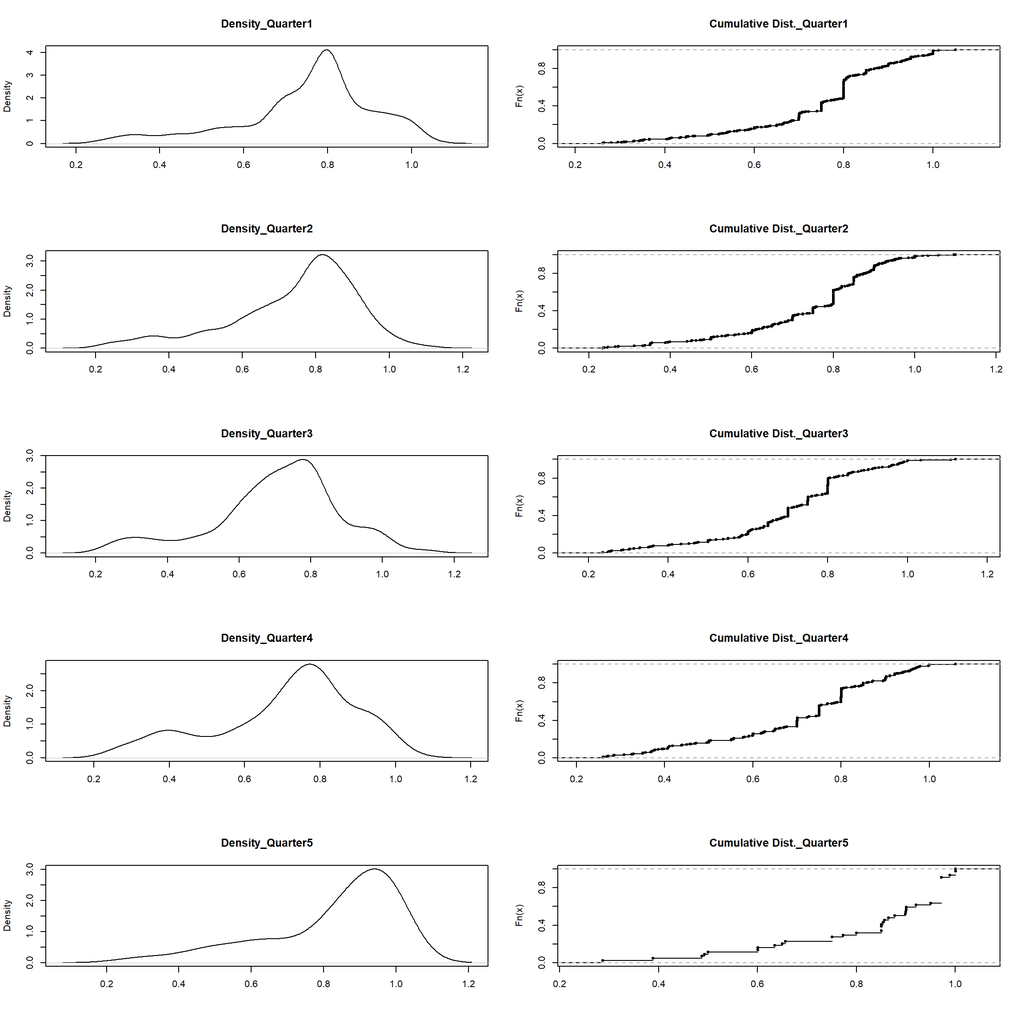

```r
# 관측 변수 기반 유형별 경험적 밀도/누적분포 시각화 함수 정의
dens <- function(x){
  par(mfrow=c(length(x),2))
  for (i in 1:length(x)){
    plot(density(x[[i]]), main= paste('Density_',names(x)[i],sep=''),xlab='')
    plot(ecdf(x[[i]]), main=paste('Cumulative Dist._',names(x)[i],sep=''), xlab='')
  }
}

# 주차, 부서, 요일에 따른 실제 및 목표 생산성 점수 분포에 대한 밀도/누적분포 도출
dens(dat_quar) #Actual
```

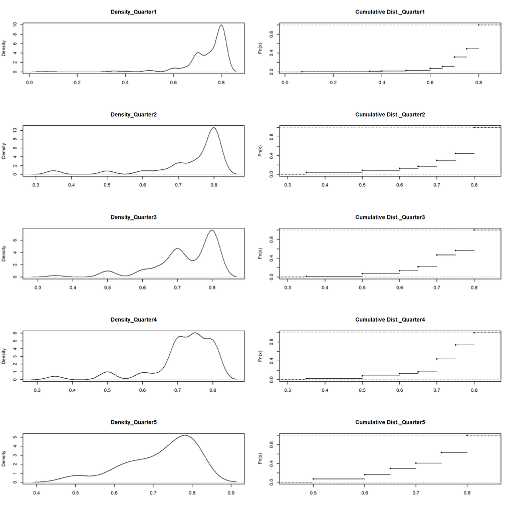

```r
dens(dat_quar1) #Targeted
```

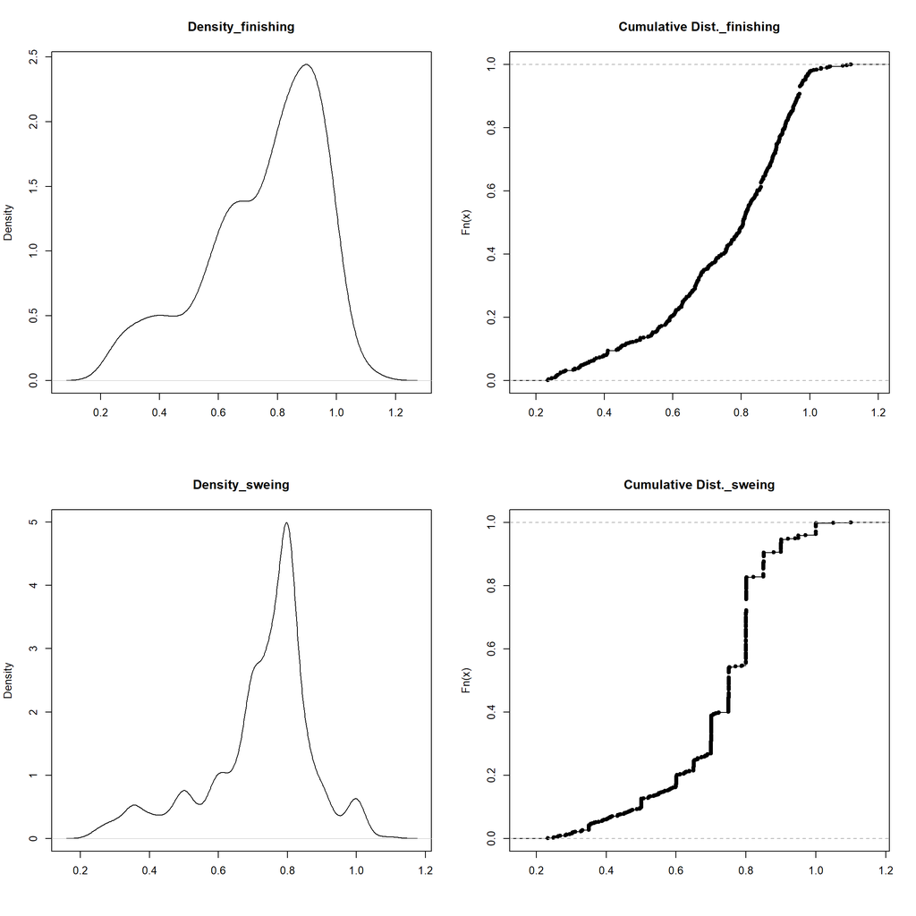

```r
dens(dat_dep) #Actual
```

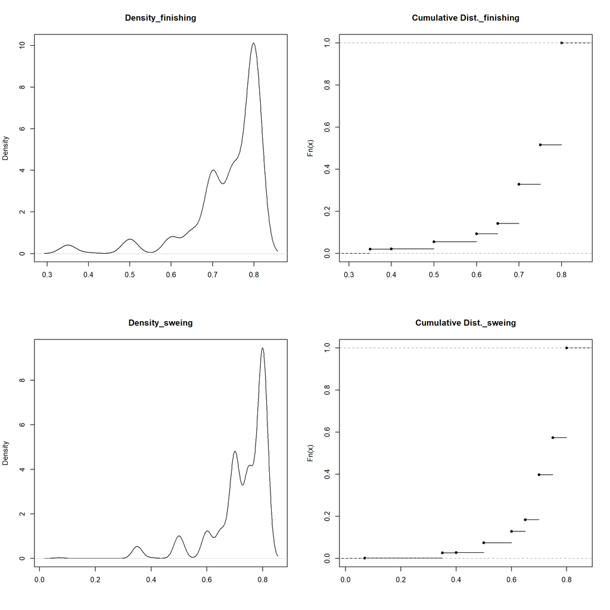

```r
dens(dat_dep1) #Targeted
```

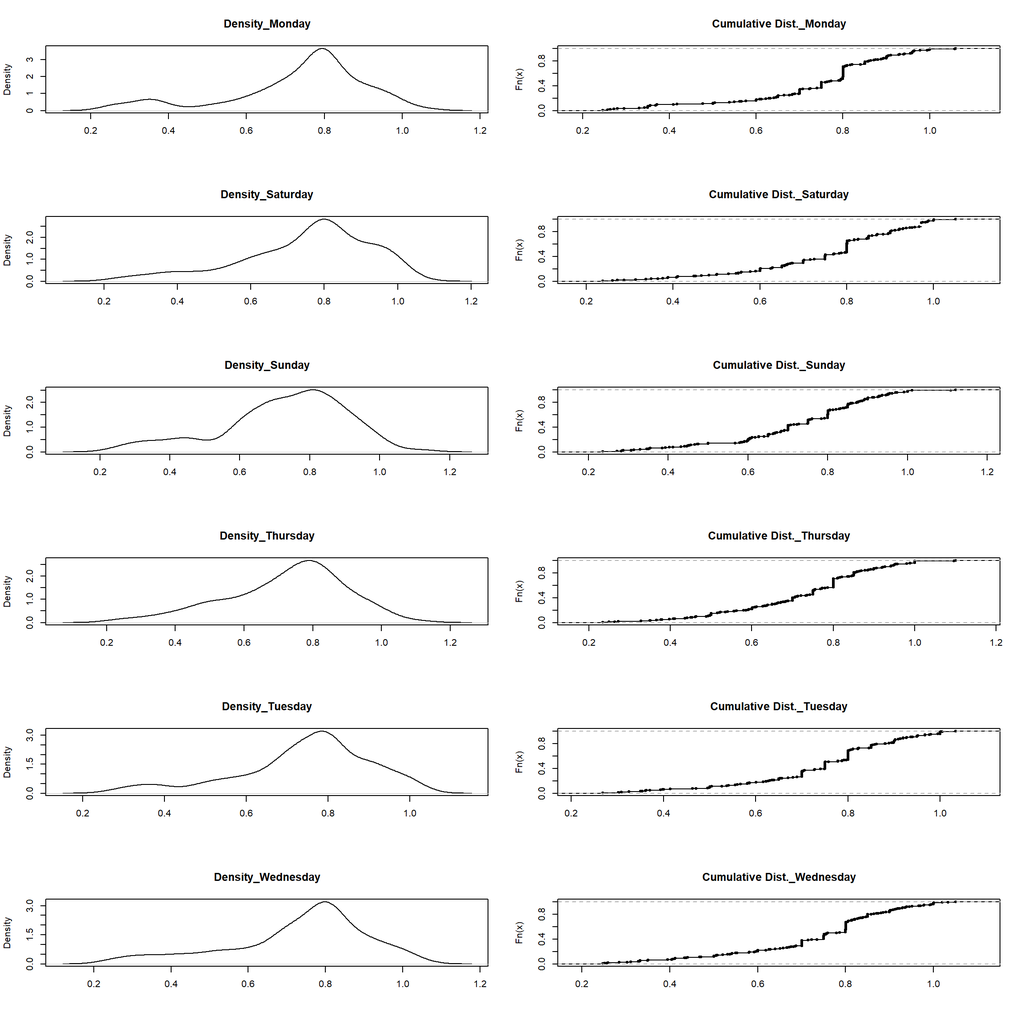

```r
dens(dat_day) #Actual
```

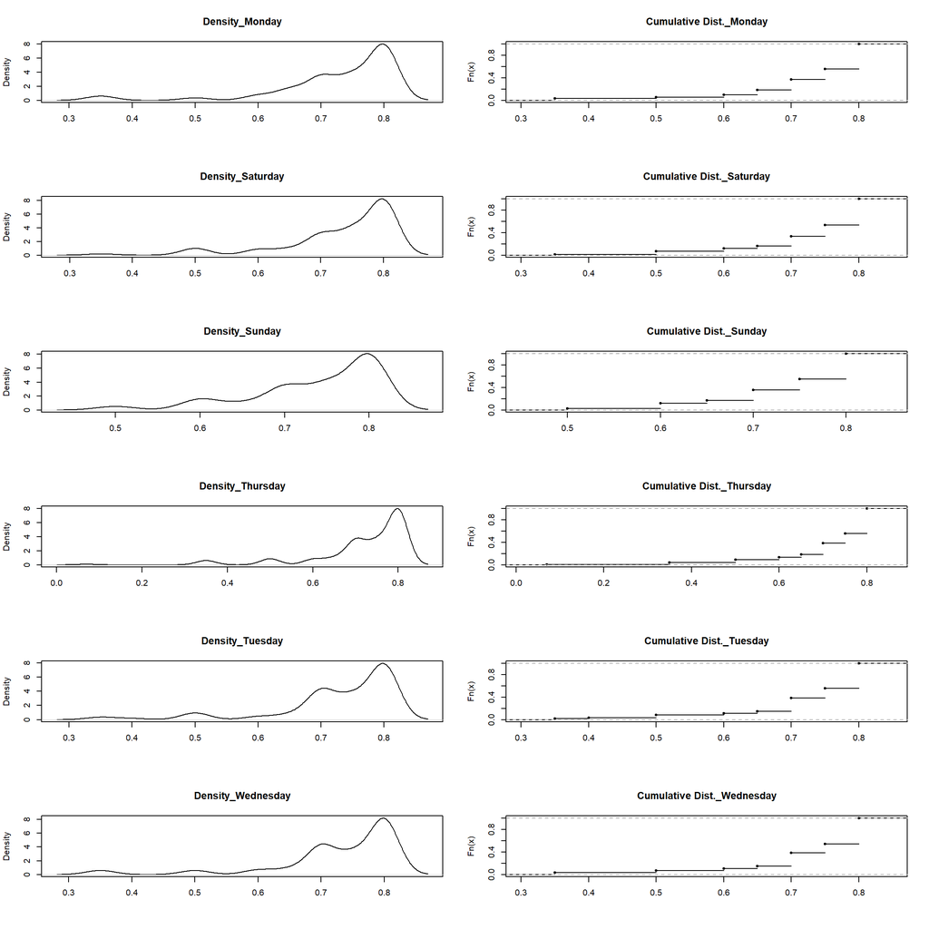

```r
dens(dat_day1) #Targeted
```

```r
# 검토 결과, 실제 생산성 점수와 목표 생상성 점수의 가장 큰 차이는  min, max값으로 보인다
# Q1, median, mean, Q3의 값은 실제와 목표치와 관계없이 유사함을 보였지만 min과 max값은 유의미한 차이가 존재하였다.
# min값의 경우, Targeted productivity > Actual productivity/ max값의 경우, Actual prod > Targeted prod를 보임
# 물론 예외도 존재함
# 주차에 따른 결과에 경우 주차가 지날 수록 목표 생산성의 최소치가 증가하였음 0.07 -> 0.500/이는 주차가 지날수록 목표치가 상승하는 것으로 보임
# 부서에 따른 결과에선 재봉 부서보다 마감 부서의 최소 목표치가 높은것을 확인 할 수 있음
# 요일에 따른 결과에선 목요일의 목표 최소치가 0.07로 제일 낮고 일요일의 목표 최소치가 0.5로 가장 높다
# 이 데이터는 한달 동안의 데이터로 달의 시작이 목요일, 끝이 일요일로 추측해볼수 있다.
```

#### 5. 부서 (department) 별로 실제 생산성 점수 (actual_productivity)의 분포에 차이가 있다고 볼 수 있는지 검정하고자 한다. 신뢰수준 99% 하에서 모평균, 모분산 가설검정을 수행하시오. (10점)

- 가설검정을 수행할 때에는 5단계의 절차를 준용하여 코드 및 설명을 작성할 것
- 모평균 검정 시 모분산은 알려지지 않았으며, 부서별 생산성 점수의 모분산은 다르다고 가정

```r
# 모평균 검정
# 가설검정
### H0: 부서간 실제 평균 생산성 점수에는 차이가 없다.
### H1: 부서간 간 실제 평균 생산성 점수에는 차이가 존재한다.

#데이터 준비
dat_dep <- split(dat_actprod, dat$department) #부서별 실제 생산성 점수

# 독립적인 두 표본에 대한 검정
# 모분산을 모른다고 가정하므로 t분포를 적용
fin <- dat_dep$finishing; swe <- dat_dep$sweing
t.test(fin, swe, var.equal=T, conf.level = 0.99)#등분산 가정
```

```
##
##  Two Sample t-test
##
## data:  fin and swe
## t = 3.0408, df = 1195, p-value = 0.002411
## alternative hypothesis: true difference in means is not equal to 0
## 99 percent confidence interval:
##  0.004688361 0.057186912
## sample estimates:
## mean of x mean of y
## 0.7529507 0.7220130
```

```r
t.test(fin, swe, var.equal=F, conf.level = 0.99)#불등분산 가정
```

```
##
##  Welch Two Sample t-test
##
## data:  fin and swe
## t = 2.9314, df = 926.17, p-value = 0.003458
## alternative hypothesis: true difference in means is not equal to 0
## 99 percent confidence interval:
##  0.003696345 0.058178928
## sample estimates:
## mean of x mean of y
## 0.7529507 0.7220130
```

```r
# 등분산 가정시 p-value값은 0.002411, 불등분산 가성지 p-value값은 0.003458으로
# 99% 신뢰구간 기준으로 0.01보다 작으므로 H0을 기각하고 H1 채택함

# 모분산 검정
# 가설검정
### H0: 부서간 실제 평균 생산성 점수의 편차는 동일하다.
### H1: 부서간 실제 평균 생산성 점수의 편차는 동일하지 않다.

# 독립적인 두 표본에 대한 검정
var.test(fin, swe, conf.level = 0.99)
```

```
##
##  F test to compare two variances
##
## data:  fin and swe
## F = 1.6202, num df = 505, denom df = 690, p-value = 4.271e-09
## alternative hypothesis: true ratio of variances is not equal to 1
## 99 percent confidence interval:
##  1.310569 2.009150
## sample estimates:
## ratio of variances
##           1.620209
```

```r
# p-value 4.271e-09이므로 99% confidence interval인 [1.310569 2.009150]에는 포함되지 않음
# 따라서, H0을 기각하고 H1 채택
```

#### 6. 부서에 따라 목표 생산성 점수 (targeted_productivity) 대비 실제로 달성한 생산성 점수 (actual_productivity)를 초과하는 비율에 차이가 있는지 살펴보고자 한다. 부서 (department) 별로 목표량을 초과하여 생산이 이루어진 비율에 차이가 있는지 95% 신뢰수준 하에서 검정을 수행하고, 달성 비율 차이에 대한 신뢰구간을 산출하시오. (15점)

- 부서별 전체 데이터 중 목표 생산성 점수가 실제 생산성 점수를 초과하는 비율이 같은지 비교할 것

```r
#가설 검정
### H0: 부서에 따라 전체 데이터 중 목표 생산성 점수가 실제 생산성 점수를 초과하는 비율은 동일하다.
### H1: 부서에 따라 전체 데이터 중 목표 생산성 점수가 실제 생산성 점수를 초과하는 비율 상이하다.

# 데이터 준비
#실제 생산성 점수가 목표 점수를 초과하면 1, 아니면 0으로 설정
dat$prod_ratio <- ifelse(dat$actual_productivity > dat$targeted_productivity, 1, 0)
#aggregate 함수를 사용하여 부서별 초과횟수을 계산
dep_exceed <- aggregate(prod_ratio ~ department, dat, FUN = sum)
dep_exceed
```

```
##   department prod_ratio
## 1  finishing        302
## 2     sweing        567
```

```r
##aggregate 함수를 사용하여 부서별 시도횟수을 계산
ndat <- aggregate(prod_ratio ~ department, dat, FUN = length)
ndat
```

```
##   department prod_ratio
## 1  finishing        506
## 2     sweing        691
```

```r
# 부서별 초과 횟수와 비초과 횟수을 나타내는 메트릭스 생성
dep_exceed_ratio <- matrix(c(dep_exceed$prod_ratio, ndat$prod_ratio - dep_exceed$prod_ratio), ncol=2, byrow=TRUE)
dep_exceed_ratio
```

```
##      [,1] [,2]
## [1,]  302  567
## [2,]  204  124
```

```r
dep_exceed_ratio1 <- matrix(c(dep_exceed$prod_ratio, ndat$prod_ratio), ncol=2, byrow=TRUE)
dep_exceed_ratio1
```

```
##      [,1] [,2]
## [1,]  302  567
## [2,]  506  691
```

```r
# 카이제곱 검정 수행
chisq_result <- chisq.test(dep_exceed_ratio)
chisq_result
```

```
##
##  Pearson's Chi-squared test with Yates' continuity correction
##
## data:  dep_exceed_ratio
## X-squared = 72.366, df = 1, p-value < 2.2e-16
```

```r
chisq.test(dep_exceed_ratio1)
```

```
##
##  Pearson's Chi-squared test with Yates' continuity correction
##
## data:  dep_exceed_ratio1
## X-squared = 11.642, df = 1, p-value = 0.0006449
```

```r
# 카이제곱 수행 결과:
# X-squared = 72.366, df = 1, p-value는 2.2e-16으로 p-value가 95% 신뢰수준보다 낮으므로
# H0를 기각하고 H1을 채택
```

#### 7. 생산 공정에 투입되는 인원 (team)이 요일 (day)에 관계없이 동일한지 검정하고자 한다. 신뢰수준 95%에서 가설검정을 수행하시오. (15점)

- 요일별로 평균적인 투입 인원을 산출할 것
- 실제 투입 인원이 요일에 관계없이 동일한 경우와 비교하여 가설검정을 수행할 것

```r
#가설 검정
### H0: 요일에 관계 없이 투입되는 인원(team)은 동일하다.
### H1: 요일에 관계 없이 투입되는 인원(team)은 동일하지 않다.

#데이터준비
# 요일별 평균적인 투입 인원 산출
day_team <- aggregate(team ~ day, data = dat, mean)

#요일별 투입 인원 수
day_team <- split(dat$team, dat$day)
ls(day_team) #금요일 데이터는 없는 것을 확인
```

```
## [1] "Monday"    "Saturday"  "Sunday"    "Thursday"  "Tuesday"   "Wednesday"
```

```r
mon <- day_team$Monday; tue <- day_team$Tuesday; wed <- day_team$Wednesday; thur <- day_team$Thursday
sat <- day_team$Saturday; sun <- day_team$Sunday

# 필요한 패키지 로드
#install.packages("car")
library(car)
# 등분산 검정 수행(chat gpt사용)
bartlett.test(list(mon, tue, wed, thur, sat, sun))
```

```
##
##  Bartlett test of homogeneity of variances
##
## data:  list(mon, tue, wed, thur, sat, sun)
## Bartlett's K-squared = 0.15737, df = 5, p-value = 0.9995
```

```r
# 등분산 검정을 결과 p-value는 0.9995이므로 신뢰수준 95%보다 높은 값을 가지고 있으므로
# H0 기각할 증거 부족, H0 채택
```

#### 8. 초과근무 시간 (over_time)과 성과급 (incentive)이 연관성이 있는지 가설검정을 통하여 확인하고자 한다. 신뢰수준 90%에서 가설검정을 수행하고, 이에 대한 결론을 도출하시오. (15점)

- 이상치를 배제하기 위하여 인센티브는 80, 초과근무는 8000 미만인 대상만 고려할 것
- 연속형 변수의 경우, 이산화를 진행하여 변수를 처리해주어야 함
- 검정을 위한 테이블은 5행 5열로 구성할 것

```r
#가설검정
### H0: 초과근무 시간 (over_time)과 성과급 (incentive)은 서로 연관성이 없다.
### H1: 초과근무 시간 (over_time)과 성과급 (incentive)은 서로 연관성이 있다.

#데이터 준비
#이상치 제거를 위해 인센티브는 80, 초과근무는 8000 미만인 대상만으로 필터링
overtime_incentive <- dat[dat$incentive < 80 & dat$over_time < 8000,]
head(overtime_incentive)
```

```
##    quarter department      day team targeted_productivity over_time incentive
## 2 Quarter1  finishing Thursday    1                  0.75       960         0
## 3 Quarter1     sweing Thursday   11                  0.80      3660        50
## 4 Quarter1     sweing Thursday   12                  0.80      3660        50
## 5 Quarter1     sweing Thursday    6                  0.80      1920        50
## 6 Quarter1     sweing Thursday    7                  0.80      6720        38
## 7 Quarter1  finishing Thursday    2                  0.75       960         0
##   actual_productivity prod_ratio
## 2           0.8865000          1
## 3           0.8005705          1
## 4           0.8005705          1
## 5           0.8003819          1
## 6           0.8001250          1
## 7           0.7551667          1
```

```r
# 연속형 변수 이산화 (chatgpt 사용)
# 두 변수를 각각 5개 구간으로 나눔
dat_overtime <- cut(overtime_incentive$over_time, breaks=5, include.lowest=TRUE)
dat_incentive <- cut(overtime_incentive$incentive, breaks=5, include.lowest=TRUE)

# 카이제곱 검정 수행
chisq.test(table(dat_overtime, dat_incentive))
```

```
##
##  Pearson's Chi-squared test
##
## data:  table(dat_overtime, dat_incentive)
## X-squared = 359.91, df = 16, p-value < 2.2e-16
```

```r
#p-value 값은 2.2e-16으로 신뢰수준 90%보다 낮은 값을 가지고 있으므로
#H0를 기각하고 H1 채택
```